# Plotting 2.0: Shiny

TheRBootcamp, http://therbootcamp.github.io

[figure not shown]

Source: https://www.rstudio.com/

### Slides

[Here are the introduction slides for this practical on Plotting 2.0: Shiny!](https://therbootcamp.github.io/_sessions/D3S3_PlottingII/PlottingII.html)

### Overview

In this practical you’ll practice creating interactive graphics with `shiny`.

### Cheatsheet

[figure not shown]

http://shiny.rstudio.com/images/shiny-cheatsheet.pdf

If you don’t have it already, you can access the `shiny` cheatsheet here http://shiny.rstudio.com/images/shiny-cheatsheet.pdf

### Examples

- Because Shiny code looks quite a bit different from standard R code, the best way to look at examples is to see a new app in action. In RStudio, click File – New File – Shiny Web App

[figure not shown]

- Save the app under the name “geyser” in a directory of your choosing

[figure not shown]

[figure not shown]

- Your app should now be up in a new window! Play around with the Number of Bins slider to see its effect on the plot

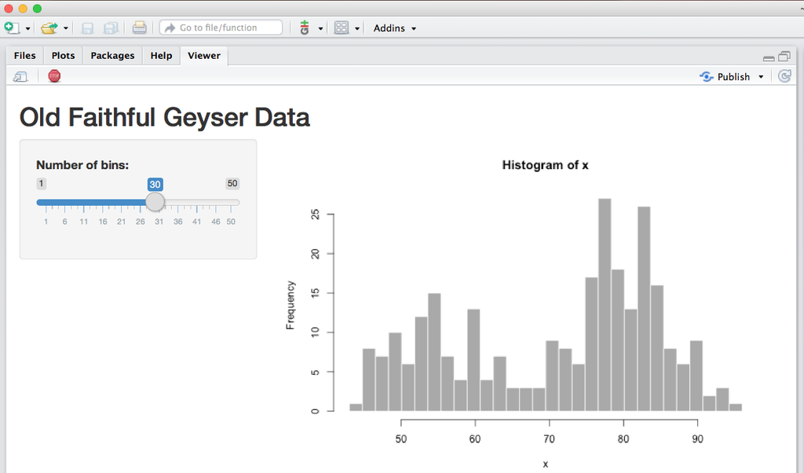

### Part A: Get started

By the end of this practical, you’ll try to create the following app:

[interactive chart not shown]

1. Start by following the example above so you have your own `geyser.app`
2. Explore the code in the app to see how it works. Where in the app is the user interface defined? Where is the server code? Where does the server code get access to the vector of geyser data? In what object is the geyser data stored?
3. Change the main title of the app from “Old Faithful Geyser Data” to “___’s first Shiny App!" using your first name.
4. In the server code, change the color of the bins of the histogram to `"red"`. Reload your app to see your changes!

#### Part B: Add a `selectInput` to change bin colors

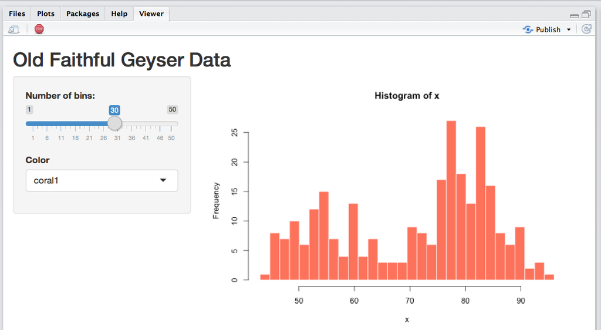

5. Now let’s add a new widget that allows the user to control the color of the histogram as a Select Box. Below the bin slider input, add a new `selectInput` like in the code below.

```r
# Add a new selectInput to your app below the sliderInput():

 sliderInput("bins",
             "Number of bins:",
             min = 1,
             max = 50,
             value = 30),   # <- Dont forget to put a comma here

 # HERE!!! Add Bin Color Select Input
 selectInput(inputId = "bincolor",
             label = "Color",
             choices = c("red", "blue", "green", "black"),
             selected = "black")
```

6. Now reload your app. You should now see a new select box on the sidebar panel. Try playing around with it by changing the color to green. Nothing happens!??! Why is that???

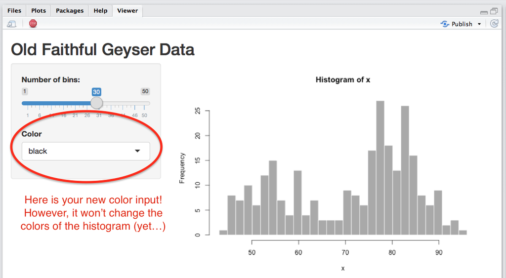

7. The problem is that we changed the input, but we haven’t told the actual plotting code in the server portion of the app (specifically `hist()`) to use the new color input! In the server portion of the app, tell the histogram to use the new color input as follows:

```r
# Make this change to the hist() function in your app
#   This will tell Shiny that the colors of the histogram
#   bins should change based on the user's input

hist(x,
     breaks = bins,
     col = input$bincolor,   # HERE!!! Change color based on input$bincolor
     border = 'white')
```

8. Now reload the app and try changing the histogram bin color using the select input. You should now see a change in the color!

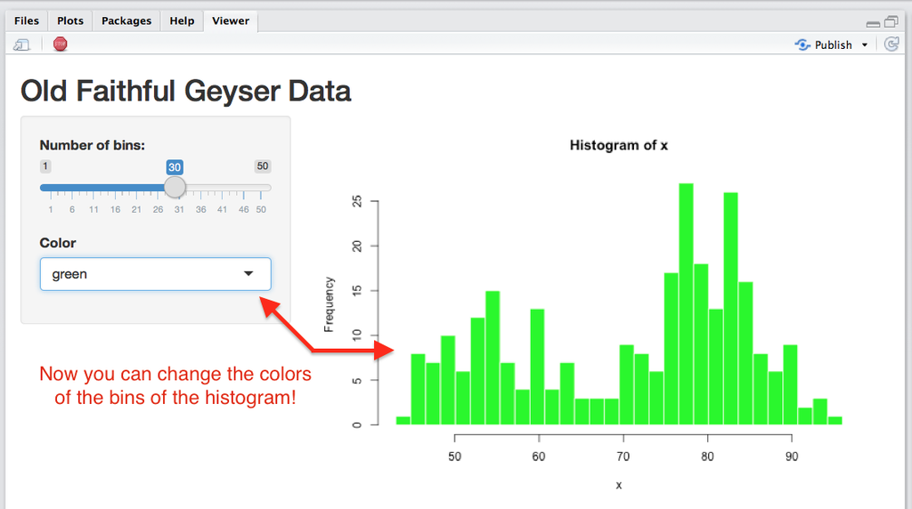

9. Right now we’ve told our color select input to have 4 possible colors by writing `choices = c("red", "blue", "green", and "black")`. But R has so many more colors, what if we wanted the select input to show all of the named colors in R like `"gold"`, `"skyblue"`, and more obscure colors like `"peachpuff4"`, `"olivedrab"` and `"lavender"`? It would be quite a pain to have to type all possible color names. Thankfully, we can easily pass a vector of color names to the `choices` input. The function `colors()` will return a vector of all 657 color names. In your console, try running `colors()` to see all of the colors.

```r
# Print a vector of all color names
colors()
```

10. Now, all we need to do to allow the select input in our app to allow all of these colors is to include the argument `choices = colors()` as follows:

```r
# This code will tell Shiny to include ALL 657 colors
#  in R as possible choices for the user in the bincolor input

 selectInput(inputId = "bincolor",
             label = "Color",
             choices = colors(), # <- HERE!!! change the choices to colors()
             selected = "black")
```

11. Now re-run your app! Your color input should now have access to *all* of the named colors in R. Try playing around with it to see the results!

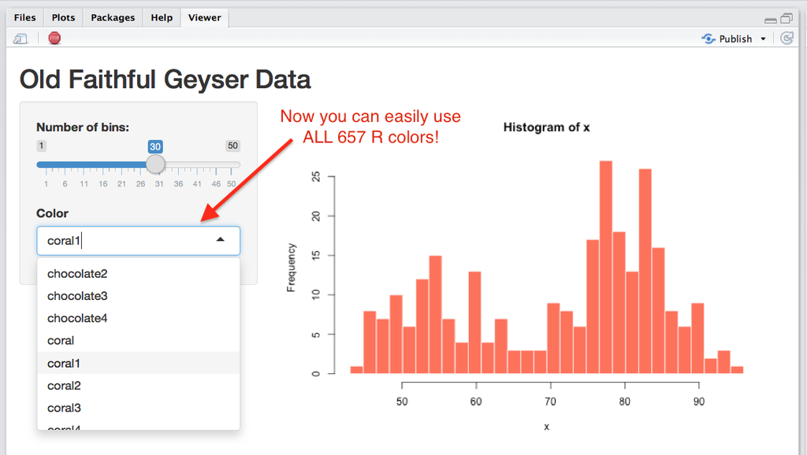

#### Part C: Add a `checkboxInput` to add mean line

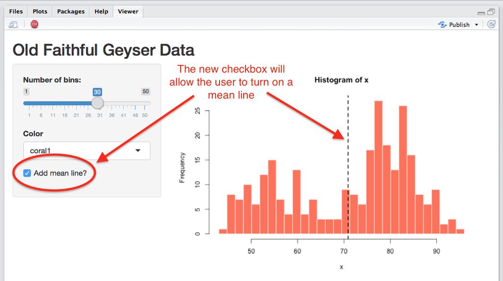

12. In this section, we’ll add a new checkbox input that allows the user to add a line indicating the mean of the distribution. In the sidebar panel, add a new checkbox input called `"addmean"`

```r
# Add a new checkboxInput to your app

checkboxInput(inputId = "addmean",
                 label = "Add mean line?",
                 value = FALSE)
```

13. Now it’s time to include the actual plotting code that will show the line. Below the `hist()` code that creates the histogram, include the following:

```r
# Add this code just below the histogram code to add
#   a line at the mean IF the addmean checkbox is checked.

if(input$addmean) {  # If the addmean box is checked...

    # Add a vertical line at the mean of x
    abline(v = mean(x),
           lwd = 2,      # Thickness
           lty = 2)      # Dashed line

  } # close if statement
```

14. Reload the app and see your new checkbox in action!

#### Part D: Add plot labels with `textInput`

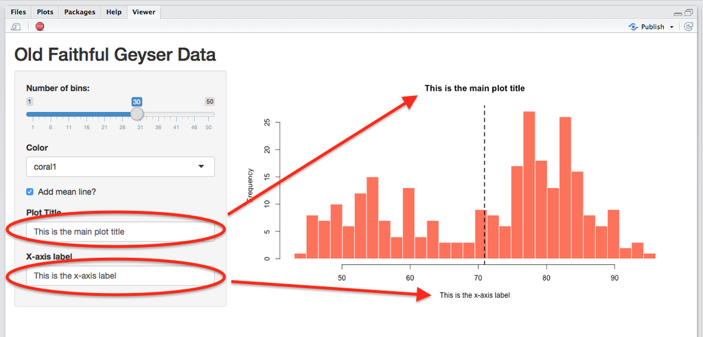

15. Now we’ll add the option for users to specify the title, and x-axis label of the plot. To do this, create two new text inputs using the `textInput()` function in the user interface.

```r
# Add 2 text inputs to the sidepanel with textinput()

textInput(inputId = "main",
          label = "Plot Title"),

textInput(inputId = "xlab",
          label = "X-axis label")
```

16. Then, include these inputs in the `hist()` function in the server code:

```r
hist(x,
     breaks = bins,
     col = input$bincolor,
     border = 'white',
     main = input$main,    # HERE!!! Change main title based on input$main
     xlab = input$xlab)    # HERE!!! Change x label  based on input$xlab
```

17. Reload the app and test your new text inputs!